# tRNA array blood cell-type meth

Richard J. Acton

2020-01-06

# 1 Introduction

Looking for blood cell-type specific DNAm patterns in tRNA genes.

Data from: GSE35069 [1]

> Six healthy male blood donors, age 38 ± 13.6 years, were included in the study. From each individual, global DNA methylation levels were analyzed in whole blood, peripheral blood mononuclear cells (PBMC) and granulocytes as well as for seven isolated cell populations (CD4+ T cells, CD8+ T cells, CD56+ NK cells, CD19+ B cells, CD14+ monocytes, neutrophils, and eosinophils), n=60 samples analyzed in total.

# 2 Set-up

## 2.1 Libs

```r
suppressPackageStartupMessages({
    library(magrittr)
    library(tidyverse)
    library(here)
    library(Biobase)
    library(GEOquery)
    library(ComplexHeatmap)
})
```

## 2.2 Env

```r
if(!dir.exists("data")) {
    dir.create("data")
}
if(!dir.exists("graphics")) {
    dir.create("graphics")
}
```

# 3 Data Read-in

```r
bltRNAs <- read_tsv(
    "../tRNA-GtRNAdb/tRNAs-in-hg19-blacklist-v2.txt",
    col_names = "tRNAname",
    col_types = "c"
) %>% pull()
```

```r
tRNAprobes <-
read_tsv(
    "../tRNA-GtRNAdb/450k_coresponding_hg19tRNAs.bed",
    col_names = c(
        "chr","start","end","probe",
        read_tsv(
            "../tRNA-GtRNAdb/std_tRNA_header.txt",
            col_types = cols(.default = col_character())
        ) %>% colnames()
    )
)
tRNAprobes %>% nrow()
```

```
[1] 213
```

```r
tRNAprobes <- tRNAprobes %>% filter(!tRNAname %in% bltRNAs)
tRNAprobes %>% nrow()
```

```
[1] 187
```

```r
tRNAgeBB <- read_delim(
    delim = "\t",
     col_names = "tRNAname",
     col_types = "c",
     file = "../tRNA-GtRNAdb/BB_GWS_tRNA.txt"
) %>%
    pull()
```

```r
swsBB23 <- read_delim(
    delim = "\t",
    col_names = "tRNAname",
    col_types = "c",
    file = "../tRNA-GtRNAdb/swsBB23.tsv"
) %>%
    pull()
```

```r
swsBB23bl <- swsBB23[!swsBB23 %in% bltRNAs]
```

```r
ctmeth <- GEOquery::getGEO("GSE35069")[[1]]
```

# 4 pre-processing

```r
metadata <- ctmeth %>% pData()
#metadata
```

```r
metadata <- readRDS(
    "data/metadata_bl.Rds"
)
tRNAmeth<- readRDS(
    file = "data/tRNAmeth_bl.Rds"
)
```

# 5 Summary Info

Data processing: The raw data from GenomeStudio software (v2011.1) methylation module (v1.9.0) were imported into R v. 2.13 and analyzed with the Bioconductor lumi package. Color channel imbalance adjusted, background corrected, and quantile normalized M values followed by fitting a Gamma distribution.

Cell categories

```r
metadata %>%
    distinct(source_name_ch1)
```

| source_name_ch1 |
| --- |
| Whole blood |
| PBMC |
| Granulocytes |
| CD4+ T cells |
| CD8+ T cells |
| CD14+ Monocytes |
| CD19+ B cells |
| CD56+ NK cells |
| Neutrophils |
| Eosinophils |

Three categories: Whole blood, PBMC, Granulocytes have other cell-types on this list within them.

Methylation data available for 187 out of 187 probes, covering 129 tRNAs. (Including 3 of the top 6 from the MeDIP-seq).

```r
myeloidLymphoid <- data.frame(
    source_name_ch1 = unique(metadata$source_name_ch1),
    myeloidLymphoid = c(NA,"lymphoid","myeloid","lymphoid","lymphoid","myeloid","lymphoid","lymphoid","myeloid","myeloid")
)

metadata <- metadata %>%
    left_join(
        myeloidLymphoid,
        by = "source_name_ch1"
    )
```

## 5.1 tRNA methylation density

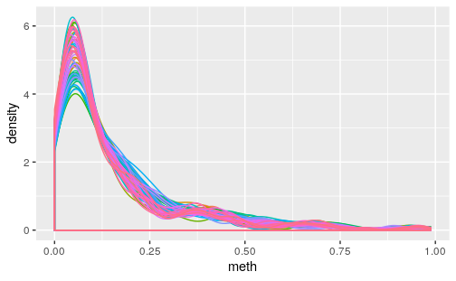

```r
tRNAmeth %>%
    as.data.frame() %>%
    rownames_to_column(var = "probe") %>%
    gather(-probe,key = "probe",value = "meth") %>%
    ggplot(aes(meth)) +
    geom_density(aes(colour = probe),show.legend = FALSE)
```

# 6 Plotting functions

Ensembl methylation colours

```r
col_fun <- circlize::colorRamp2(c(0, 0.5, 1), c("#ffff00", "#19ff00", "#0033cc"))
```

# 7 initial inspection

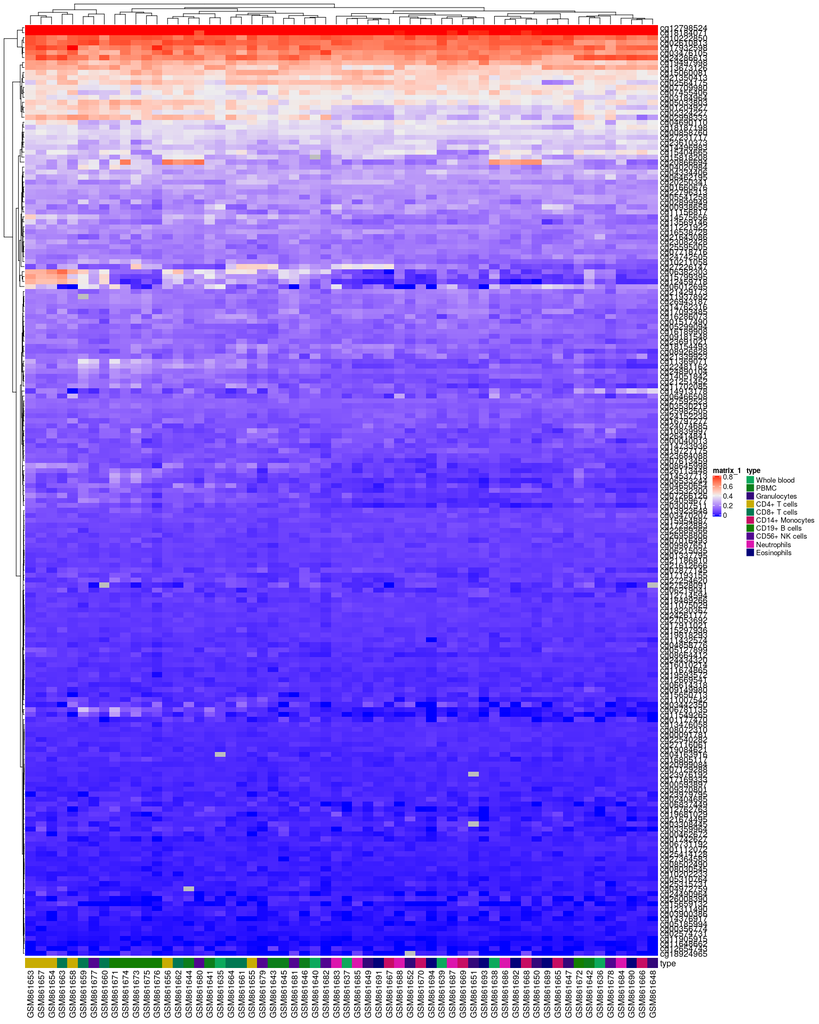

```r
ComplexHeatmap::Heatmap(
    tRNAmeth,
    bottom_annotation = HeatmapAnnotation(type = metadata$`tissue/cell type:ch1`)
)
```